# R 語言特訓班 2：資料輸入與整理

黃大維，臺灣大學統計碩士

2018年8月1日

## 2-1：資料分析的流程

每個分析階段的重要步驟如下圖所示：

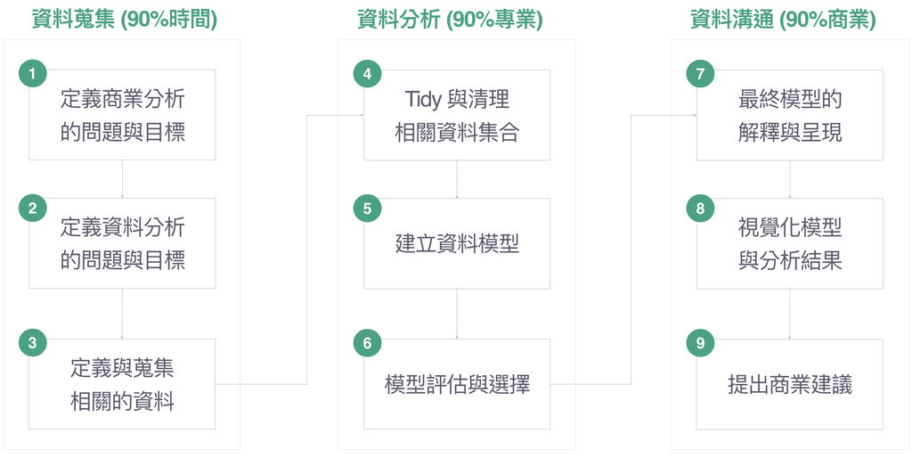

實際上，在 R 語言中能夠處理的是上圖的步驟 4 - 8，RStudio 首席科學家 Hadley Wickham 的書中則是以下圖方式呈現：

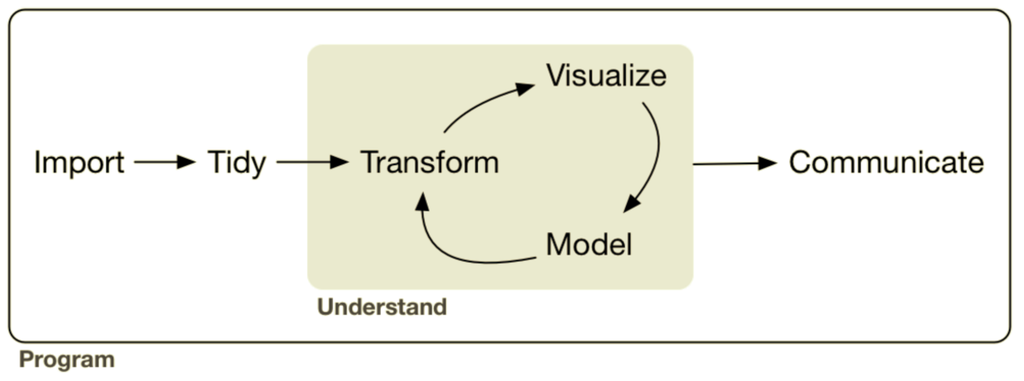

在這門課程中，我們會介紹如何在 tidyverse 架構下，進行資料的輸入 (Import)、整理 (Tidy)，轉換 (Transformation) 與整合 (Integration) 則會在後面的課程中討論。

首先，我們安裝 `tidyverse` 套件包，裡面有許多我們未來會使用到的套件（如：`dplyr`, `ggplot2` 等）。

```r
install.packages("tidyverse")
```

如果你像我一樣很懶惰的話，就直接使用 tidyverse 的所有套件吧！

```r
library("tidyverse")
```

## 2-2：Tibble — 新型態的資料框架

`tibble` 是 R 語言中獨有的資料架構，改善了 `data.frame` 的一些缺點，與 `data.frame` 有類似的語法，但使用起來更方便。

### 1. 如何建立 tibble 物件

首先，我們先來看看如何將一個不是 `tibble` 的物件轉換成 `tibble` 物件。從下列程式碼中，你會發現 `tibble` 物件 的第一個好處，他不會一次 print 出所有的資料，而是只印出前十列 (row)。

```r
library(tibble)

iris
```

```
##     Sepal.Length Sepal.Width Petal.Length Petal.Width    Species
## 1            5.1         3.5          1.4         0.2     setosa
## 2            4.9         3.0          1.4         0.2     setosa
## 3            4.7         3.2          1.3         0.2     setosa
## 4            4.6         3.1          1.5         0.2     setosa
## 5            5.0         3.6          1.4         0.2     setosa
## 6            5.4         3.9          1.7         0.4     setosa
## 7            4.6         3.4          1.4         0.3     setosa
## 8            5.0         3.4          1.5         0.2     setosa
## 9            4.4         2.9          1.4         0.2     setosa
## 10           4.9         3.1          1.5         0.1     setosa
## 11           5.4         3.7          1.5         0.2     setosa
## 12           4.8         3.4          1.6         0.2     setosa
## 13           4.8         3.0          1.4         0.1     setosa
## 14           4.3         3.0          1.1         0.1     setosa
```

[output cut: 136 more lines]

```r
iris2 <- as_tibble(iris)
iris2
```

```
## # A tibble: 150 x 5
##    Sepal.Length Sepal.Width Petal.Length Petal.Width Species
##           <dbl>       <dbl>        <dbl>       <dbl> <fct>
##  1          5.1         3.5          1.4         0.2 setosa
##  2          4.9         3            1.4         0.2 setosa
##  3          4.7         3.2          1.3         0.2 setosa
##  4          4.6         3.1          1.5         0.2 setosa
##  5          5           3.6          1.4         0.2 setosa
##  6          5.4         3.9          1.7         0.4 setosa
##  7          4.6         3.4          1.4         0.3 setosa
##  8          5           3.4          1.5         0.2 setosa
##  9          4.4         2.9          1.4         0.2 setosa
## 10          4.9         3.1          1.5         0.1 setosa
## # ... with 140 more rows
```

我們也可以用變數/欄 (column) 來建立 `tibble` 物件。

```r
tibble(x = 1:5, y = 1, z = x ^ 2 + y)
```

```
## # A tibble: 5 x 3
##       x     y     z
##   <int> <dbl> <dbl>
## 1     1     1     2
## 2     2     1     5
## 3     3     1    10
## 4     4     1    17
## 5     5     1    26
```

如果想要用個體/列 (row) 來建立 `tibble` 物件，可以使用 `tribble`。

```r
tribble(
  ~x, ~y,  ~z,
  "a", 2,  3.6,
  "b", 1,  8.5
)
```

```
## # A tibble: 2 x 3
##   x         y     z
##   <chr> <dbl> <dbl>
## 1 a         2   3.6
## 2 b         1   8.5
```

想要在已經建立好的 `tibble` 物件中建立新的 row 與 column，可以利用 `add_row` 與 `add_column` 函數。

```r
df <- tibble(x = 1:3, y = 3:1)

# add_row
add_row(df, x = 4, y = 0)
```

```
## # A tibble: 4 x 2
##       x     y
##   <dbl> <dbl>
## 1     1     3
## 2     2     2
## 3     3     1
## 4     4     0
```

```r
# You can specify where to add the new rows
add_row(df, x = 4, y = 0, .before = 2)
```

```
## # A tibble: 4 x 2
##       x     y
##   <dbl> <dbl>
## 1     1     3
## 2     4     0
## 3     2     2
## 4     3     1
```

```r
# You can supply vectors, to add multiple rows (this isn't
# recommended because it's a bit hard to read)
add_row(df, x = 4:5, y = 0:-1)
```

```
## # A tibble: 5 x 2
##       x     y
##   <int> <int>
## 1     1     3
## 2     2     2
## 3     3     1
## 4     4     0
## 5     5    -1
```

```r
# Absent variables get missing values
add_row(df, x = 4)
```

```
## # A tibble: 4 x 2
##       x     y
##   <dbl> <int>
## 1     1     3
## 2     2     2
## 3     3     1
## 4     4    NA
```

```r
#add_column
add_column(df, z = -1:1, w = 0)
```

```
## # A tibble: 3 x 4
##       x     y     z     w
##   <int> <int> <int> <dbl>
## 1     1     3    -1     0
## 2     2     2     0     0
## 3     3     1     1     0
```

如果想將兩個不同的資料集合合併在一起，可以使用 `dplyr` 套件中的 `bind_rows` 與 `bind_cols` 函數。

```r
library(dplyr)

bind_rows(iris2[1:5, ], iris2[6:10, ])
```

```
## # A tibble: 10 x 5
##    Sepal.Length Sepal.Width Petal.Length Petal.Width Species
##           <dbl>       <dbl>        <dbl>       <dbl> <fct>
##  1          5.1         3.5          1.4         0.2 setosa
##  2          4.9         3            1.4         0.2 setosa
##  3          4.7         3.2          1.3         0.2 setosa
##  4          4.6         3.1          1.5         0.2 setosa
##  5          5           3.6          1.4         0.2 setosa
##  6          5.4         3.9          1.7         0.4 setosa
##  7          4.6         3.4          1.4         0.3 setosa
##  8          5           3.4          1.5         0.2 setosa
##  9          4.4         2.9          1.4         0.2 setosa
## 10          4.9         3.1          1.5         0.1 setosa
```

```r
bind_cols(iris2[, 1:2], iris2[, 3:4])
```

```
## # A tibble: 150 x 4
##    Sepal.Length Sepal.Width Petal.Length Petal.Width
##           <dbl>       <dbl>        <dbl>       <dbl>
##  1          5.1         3.5          1.4         0.2
##  2          4.9         3            1.4         0.2
##  3          4.7         3.2          1.3         0.2
##  4          4.6         3.1          1.5         0.2
##  5          5           3.6          1.4         0.2
##  6          5.4         3.9          1.7         0.4
##  7          4.6         3.4          1.4         0.3
##  8          5           3.4          1.5         0.2
##  9          4.4         2.9          1.4         0.2
## 10          4.9         3.1          1.5         0.1
## # ... with 140 more rows
```

### 2. Tibble 與 data.frame 的差異

除了 print 的差別外， `tibble` 除去了 `data.frame` 一個容易出錯的功能 - 部分比對：

```r
df <- data.frame(
  abc = 1:10,
  def = runif(10),
  xyz = sample(letters, 10)
)
tb <- as_tibble(df)

df$a
```

```
##  [1]  1  2  3  4  5  6  7  8  9 10
```

```r
tb$a
```

[output not shown]

另外， `data.frame` 在選取子集合時會回傳向量，但 `tibble` 仍會回傳 `tibble` 物件。

```r
# With data frames, [ sometimes returns a data frame, and sometimes
# returns a vector
df[, 1]
```

```
##  [1]  1  2  3  4  5  6  7  8  9 10
```

```r
df[, 1:2]
```

```
##    abc        def
## 1    1 0.96293346
## 2    2 0.79141904
## 3    3 0.76365864
## 4    4 0.74599174
## 5    5 0.04437549
## 6    6 0.81406875
## 7    7 0.56417055
## 8    8 0.32442550
## 9    9 0.17488077
## 10  10 0.08112289
```

```r
# With tibbles, [ always returns another tibble
tb[, 1]
```

```
## # A tibble: 10 x 1
##      abc
##    <int>
##  1     1
##  2     2
##  3     3
##  4     4
##  5     5
##  6     6
##  7     7
##  8     8
##  9     9
## 10    10
```

```r
tb[, 1:2]
```

```
## # A tibble: 10 x 2
##      abc    def
##    <int>  <dbl>
##  1     1 0.963
##  2     2 0.791
##  3     3 0.764
##  4     4 0.746
##  5     5 0.0444
##  6     6 0.814
##  7     7 0.564
##  8     8 0.324
##  9     9 0.175
## 10    10 0.0811
```

```r
# To extract a single element, you should always use [[
tb[[1]]
```

```
##  [1]  1  2  3  4  5  6  7  8  9 10
```

### 3. Tibble 的缺點

跟 `data.frame` 相比， `tibble` 對使用者來說更方便一些，但最大的缺點就是比較老的套件可能會不支援 `tibble` 物件，這時必須轉換回 `data.frame`。

```r
class(as.data.frame(tb))
```

```
## [1] "data.frame"
```

## 2-3：資料輸入與輸出 (Data Import and Export)

### 1. 輸入 csv 類型的資料

一般我們儲存的 csv 資料檔案都遵循以下架構（來源：維基百科）：

1. 純文字，使用某個字元集，比如ASCII、Unicode、EBCDIC或GB2312（簡體中文環境）等；
2. 由記錄組成（典型的是每行一條記錄）；
3. 每條記錄被分隔符分隔為欄位（典型分隔符有逗號、分號或制表符；有時分隔符可以包括可選的空格）；
4. 每條記錄都有同樣的欄位序列。

下圖可以更清楚的理解資料檔案的格式：

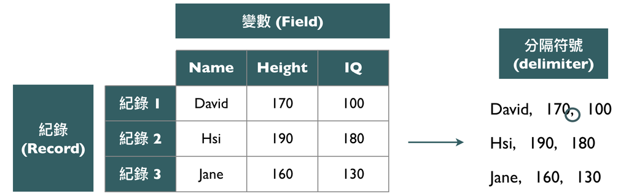

在 `tidyverse` 架構下，資料輸入與輸出的函數都存在於套件 `readr` 中，此處只介紹讀取上述類型的檔案。

- `read_csv()`：分隔符號為 , 的檔案
- `read_csv2()`：分隔符號為 ; 的檔案（有些國家的小數點以 , 表示，就會出現這類檔案
- `read_tsv()`：分隔符號為 tab 的檔案
- `read_delim()`：可以自行選擇分隔符號

在這裡我們提供 file1, file2, file3, file4 作為範例，分別對應上述的四種情境。

```r
library(readr)

read_csv("file1.csv")
```

```
## # A tibble: 2 x 3
##       a     b     c
##   <int> <int> <int>
## 1     1     2     3
## 2     4     5    NA
```

```r
read_csv2("file2.csv")
```

```
## Using ',' as decimal and '.' as grouping mark. Use read_delim() for more control.
```

```
## # A tibble: 2 x 3
##       a     b     c
##   <int> <int> <int>
## 1     1     2     3
## 2     4     5    NA
```

```r
read_delim("file3.txt", delim = "|")
```

```
## # A tibble: 2 x 3
##       a     b     c
##   <int> <int> <int>
## 1     1     2     3
## 2     4     5    NA
```

```r
read_tsv("file4.tsv")
```

```
## # A tibble: 2 x 3
##       a     b     c
##   <int> <int> <int>
## 1     1     2     3
## 2     4     5    NA
```

如果你想了解更多參數設定，請看文件： https://www.rdocumentation.org/packages/readr/versions/1.1.1/topics/read_delim 。

### 2. 輸出 csv 檔案

`read_csv()`，`read_csv2()`，`read_delim()`，`read_tsv()` 都有對應的 `write_csv()` 等函數，語法為： `write_csv(tibble 物件, 檔案名稱, ...)`。

```r
write_delim(read_delim("file3.txt", delim = "|"),
            "file3_write.txt", delim = "|")
```

### 3. 輸入 EXCEL 檔案

`tidyverse` 架構下要讀取 EXCEL 檔案，會使用 `readxl` 套件。

```r
# install.packages("readxl")
library(readxl)

# List the sheet names with excel_sheets().
excel_sheets("datasets.xlsx")
```

```
## [1] "iris"     "mtcars"   "chickwts" "quakes"
```

```r
# read_excel() reads both xls and xlsx files and detects the format from the extension.
read_excel("datasets.xlsx")
```

```
## # A tibble: 150 x 5
##    Sepal.Length Sepal.Width Petal.Length Petal.Width Species
##           <dbl>       <dbl>        <dbl>       <dbl> <chr>
##  1          5.1         3.5          1.4         0.2 setosa
##  2          4.9         3            1.4         0.2 setosa
##  3          4.7         3.2          1.3         0.2 setosa
##  4          4.6         3.1          1.5         0.2 setosa
##  5          5           3.6          1.4         0.2 setosa
##  6          5.4         3.9          1.7         0.4 setosa
##  7          4.6         3.4          1.4         0.3 setosa
##  8          5           3.4          1.5         0.2 setosa
##  9          4.4         2.9          1.4         0.2 setosa
## 10          4.9         3.1          1.5         0.1 setosa
## # ... with 140 more rows
```

可以選擇特定的活頁簿 (worksheets) 輸入（如果不指定活頁簿，會輸入檔案中的第一個活頁簿）。

```r
read_excel("datasets.xlsx", sheet = "chickwts")
```

```
## # A tibble: 71 x 2
##    weight feed
##     <dbl> <chr>
##  1    179 horsebean
##  2    160 horsebean
##  3    136 horsebean
##  4    227 horsebean
##  5    217 horsebean
##  6    168 horsebean
##  7    108 horsebean
##  8    124 horsebean
##  9    143 horsebean
## 10    140 horsebean
## # ... with 61 more rows
```

```r
read_excel("datasets.xlsx", sheet = 4)
```

```
## # A tibble: 1,000 x 5
##      lat  long depth   mag stations
##    <dbl> <dbl> <dbl> <dbl>    <dbl>
##  1 -20.4  182.   562   4.8       41
##  2 -20.6  181.   650   4.2       15
##  3 -26    184.    42   5.4       43
##  4 -18.0  182.   626   4.1       19
##  5 -20.4  182.   649   4         11
##  6 -19.7  184.   195   4         12
##  7 -11.7  166.    82   4.8       43
##  8 -28.1  182.   194   4.4       15
##  9 -28.7  182.   211   4.7       35
## 10 -17.5  180.   622   4.3       19
## # ... with 990 more rows
```

以下有一些用來選取輸入範圍的範例。

```r
read_excel("datasets.xlsx", n_max = 3)
```

```
## # A tibble: 3 x 5
##   Sepal.Length Sepal.Width Petal.Length Petal.Width Species
##          <dbl>       <dbl>        <dbl>       <dbl> <chr>
## 1          5.1         3.5          1.4         0.2 setosa
## 2          4.9         3            1.4         0.2 setosa
## 3          4.7         3.2          1.3         0.2 setosa
```

```r
read_excel("datasets.xlsx", range = "C1:E4")
```

```
## # A tibble: 3 x 3
##   Petal.Length Petal.Width Species
##          <dbl>       <dbl> <chr>
## 1          1.4         0.2 setosa
## 2          1.4         0.2 setosa
## 3          1.3         0.2 setosa
```

```r
read_excel("datasets.xlsx", range = cell_rows(1:4))
```

```
## # A tibble: 3 x 5
##   Sepal.Length Sepal.Width Petal.Length Petal.Width Species
##          <dbl>       <dbl>        <dbl>       <dbl> <chr>
## 1          5.1         3.5          1.4         0.2 setosa
## 2          4.9         3            1.4         0.2 setosa
## 3          4.7         3.2          1.3         0.2 setosa
```

```r
read_excel("datasets.xlsx", range = cell_cols("B:D"))
```

```
## # A tibble: 150 x 3
##    Sepal.Width Petal.Length Petal.Width
##          <dbl>        <dbl>       <dbl>
##  1         3.5          1.4         0.2
##  2         3            1.4         0.2
##  3         3.2          1.3         0.2
##  4         3.1          1.5         0.2
##  5         3.6          1.4         0.2
##  6         3.9          1.7         0.4
##  7         3.4          1.4         0.3
##  8         3.4          1.5         0.2
##  9         2.9          1.4         0.2
## 10         3.1          1.5         0.1
## # ... with 140 more rows
```

```r
read_excel("datasets.xlsx", range = "mtcars!B1:D5")
```

```
## # A tibble: 4 x 3
##     cyl  disp    hp
##   <dbl> <dbl> <dbl>
## 1     6   160   110
## 2     6   160   110
## 3     4   108    93
## 4     6   258   110
```

也可以將特定值設為 `NA` 值。

```r
read_excel("datasets.xlsx", na = "setosa")
```

```
## # A tibble: 150 x 5
##    Sepal.Length Sepal.Width Petal.Length Petal.Width Species
##           <dbl>       <dbl>        <dbl>       <dbl> <chr>
##  1          5.1         3.5          1.4         0.2 <NA>
##  2          4.9         3            1.4         0.2 <NA>
##  3          4.7         3.2          1.3         0.2 <NA>
##  4          4.6         3.1          1.5         0.2 <NA>
##  5          5           3.6          1.4         0.2 <NA>
##  6          5.4         3.9          1.7         0.4 <NA>
##  7          4.6         3.4          1.4         0.3 <NA>
##  8          5           3.4          1.5         0.2 <NA>
##  9          4.4         2.9          1.4         0.2 <NA>
## 10          4.9         3.1          1.5         0.1 <NA>
## # ... with 140 more rows
```

### 4. 輸出 EXCEL 檔案

- 目前 `readxl` 套件還沒有支援輸出 EXCEL 檔案的函數，大家可以考慮套件 https://github.com/ropensci/writexl 。
- 我自己的習慣是輸入輸出直接完全採用 `xlsx` 套件（https://www.rdocumentation.org/packages/xlsx/versions/0.5.7 ）。

## 2-4：Tidy 你的資料集合

`Tidy Data` 是由 R Studio 首席科學家 Hadley Wickham 所提出，是一種「資料架構標準」。傳統的資料清理 (data cleansing) 著重於「整理雜亂的資料」，然而有些整理乾淨的資料反而不利於分析（之後會看到一些例子，最直接的例子就是 EXCEL 的樞紐分析表 - 雖然整理的很乾淨，但非常難以運用到其他加值運算）。

Wickham 提出了 data tidying 的概念 - 結構化現有的資料集合以利後續分析 （structuring datasets to facilitate analysis）。如果你跟 SQL 和關聯資料庫 (relational database) 很熟悉，那麼你會發現 Tidy data 的原則跟關聯性資料庫其實是一樣的！

### 1. 什麼是 Tidy Data

一個 Tidy Dataset 會滿足以下三個條件（如下圖所示）：

- 每個變數 (variale) 都會形成一個 column
- 每個觀察個體 (observation) 都會形成一個 row
- 每一種類型的觀察個體會形成一個 table，比如說：地區特徵跟個體資料應該存成兩個不同的資料表格。

如果大家跟關聯資料庫熟悉的話，會發現其實這就是所謂的正規化原則 (normal principle)。

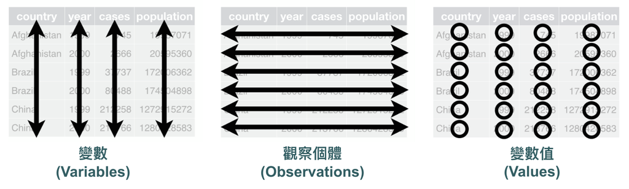

### 2. 常見的非 Tidy 資料

通常 non-tidy data 有四種可能性，針對這四種可能性，`tidyr` 套件有四個常見的函數可以幫助你將不符合 tidy 原則的資料集合整理成 tidy data。

```r
library(tidyr)
```

#### Column 其實是值而不是變數 - 使用 Gather

在這裡一定要特別提，什麼叫做變數 (variale) 呢？ 通常變數是「某種處置 (treatment)」產生的，比如說：`is_male` 、`age` 是一個合理的變數，但下面這個資料集合的變數卻怪怪的…

```r
pew <- read_delim(
  "http://stat405.had.co.nz/data/pew.txt",
  delim = "\t"
)
print(pew)
```

```
## # A tibble: 18 x 11
##    religion      `<$10k` `$10-20k` `$20-30k` `$30-40k` `$40-50k` `$50-75k`
##    <chr>           <int>     <int>     <int>     <int>     <int>     <int>
##  1 Agnostic           27        34        60        81        76       137
##  2 Atheist            12        27        37        52        35        70
##  3 Buddhist           27        21        30        34        33        58
##  4 Catholic          418       617       732       670       638      1116
##  5 Don’t know/r…      15        14        15        11        10        35
##  6 Evangelical …     575       869      1064       982       881      1486
##  7 Hindu               1         9         7         9        11        34
##  8 Historically…     228       244       236       238       197       223
##  9 Jehovah's Wi…      20        27        24        24        21        30
## 10 Jewish             19        19        25        25        30        95
## 11 Mainline Prot     289       495       619       655       651      1107
## 12 Mormon             29        40        48        51        56       112
## 13 Muslim              6         7         9        10         9        23
## 14 Orthodox           13        17        23        32        32        47
## 15 Other Christ…       9         7        11        13        13        14
## 16 Other Faiths       20        33        40        46        49        63
## 17 Other World …       5         2         3         4         2         7
## 18 Unaffiliated      217       299       374       365       341       528
## # ... with 4 more variables: `$75-100k` <int>, `$100-150k` <int>,
## #   `>150k` <int>, `Don't know/refused` <int>
```

你有沒有發現，其實這個資料集合的 column 是 `income` 這個變數的數值呢？此時，我們可以利用 `gather` 這個指令把這些散落的數值找回來。該指令的敘述如下：

```r
gather(data,
       key = "key",
       value = "value",
       ...,
       na.rm = FALSE,
       convert = FALSE,
       factor_key = FALSE)
```

其中最重要的函數輸入有四個部分：

- data：待處理的資料
- key：新變數的欄位名稱
- value：新變數變數值的儲存欄位名稱
- …：要被蒐集起來變成新變數的 columns

以上述 `pew` 資料的案例，我們可以用以下程式碼改正：

```r
# Get column names
pew.colnames <- colnames(pew)

# Gather values and form it as a new column
pew.new <- pew %>%
  gather(key = "income",
         value = "cases",
         pew.colnames[2:ncol(pew)])

print(pew.new)
```

```
## # A tibble: 180 x 3
##    religion                income cases
##    <chr>                   <chr>  <int>
##  1 Agnostic                <$10k     27
##  2 Atheist                 <$10k     12
##  3 Buddhist                <$10k     27
##  4 Catholic                <$10k    418
##  5 Don’t know/refused      <$10k     15
##  6 Evangelical Prot        <$10k    575
##  7 Hindu                   <$10k      1
##  8 Historically Black Prot <$10k    228
##  9 Jehovah's Witness       <$10k     20
## 10 Jewish                  <$10k     19
## # ... with 170 more rows
```

大家在是不是很疑問怎麼出現了 `%>%` 符號呢？這個符號叫做 pipe 運算元，它的作用是將左側的運算結果傳遞至右側函數的第一個參數。所以上述案例中，`pew %>% gather(..., pew.colnames[2:ncol(pew)])` 代表我們把 `pew` 指定成 `gather` 函數的第一個參數，也就是資料集合。

由於 R 裡面許多函數的第一個欄位都是資料集合，運用 `%>%` 其實可以很輕易的將我們把多個函數串連在一起，不用將每個函數運算的結果都指定成一個新變數，浪費記憶體空間。

#### 把變數當成值 - 使用 spread

有時候，工程師因為不知道最後到底會有幾個變數，所以把變數當成值來儲存，保持彈性，但這樣的資料架構其實相當難用在後續的分析中。下列資料就是「把 variables 當成 value 存在同一個 column」的情況，資料很明顯把 `cases` 與 `population` 兩個變數存在同一個 column：

```r
table2
```

```
## # A tibble: 12 x 4
##    country      year type            count
##    <chr>       <int> <chr>           <int>
##  1 Afghanistan  1999 cases             745
##  2 Afghanistan  1999 population   19987071
##  3 Afghanistan  2000 cases            2666
##  4 Afghanistan  2000 population   20595360
##  5 Brazil       1999 cases           37737
##  6 Brazil       1999 population  172006362
##  7 Brazil       2000 cases           80488
##  8 Brazil       2000 population  174504898
##  9 China        1999 cases          212258
## 10 China        1999 population 1272915272
## 11 China        2000 cases          213766
## 12 China        2000 population 1280428583
```

這時，我們可以用 `spread` 指令把這些變數分開。`spread` 其實就是 `gather` 的相反，該指令的敘述如下：

```r
spread(data,
       key,
       value,
       fill = NA,
       convert = FALSE,
       drop = TRUE,
       sep = NULL)
```

其中比較重要的參數有：

- key：要被拆開成 variables 的 column
- sep：如果是 `NULL`，回直接將 key 的值當成新 columns 的名稱，如果輸入其他分隔符號，會回傳：“paste0(key_name,sep,key_value)”。

因此，上述資料可以如此整理：

```r
table2 %>%
  spread(key = type,
         value = count)
```

```
## # A tibble: 6 x 4
##   country      year  cases population
##   <chr>       <int>  <int>      <int>
## 1 Afghanistan  1999    745   19987071
## 2 Afghanistan  2000   2666   20595360
## 3 Brazil       1999  37737  172006362
## 4 Brazil       2000  80488  174504898
## 5 China        1999 212258 1272915272
## 6 China        2000 213766 1280428583
```

```r
table2 %>%
  spread(key = type,
         value = count,
         sep = '_')
```

```
## # A tibble: 6 x 4
##   country      year type_cases type_population
##   <chr>       <int>      <int>           <int>
## 1 Afghanistan  1999        745        19987071
## 2 Afghanistan  2000       2666        20595360
## 3 Brazil       1999      37737       172006362
## 4 Brazil       2000      80488       174504898
## 5 China        1999     212258      1272915272
## 6 China        2000     213766      1280428583
```

#### 多個變數儲存在同一個 column 中 - 使用 separate

下面是一個更混亂的資料集合：

```r
tb <- read_csv("tb.csv")
print(tb)
```

```
## # A tibble: 5,769 x 23
##    iso2   year new_sp `m_0-4` `m_5-14` `m_0-14` `m_15-24` `m_25-34`
##    <chr> <int>  <int>   <int>    <int>    <int>     <int>     <int>
##  1 AD     1989     NA      NA       NA       NA        NA        NA
##  2 AD     1990     NA      NA       NA       NA        NA        NA
##  3 AD     1991     NA      NA       NA       NA        NA        NA
##  4 AD     1992     NA      NA       NA       NA        NA        NA
##  5 AD     1993     15      NA       NA       NA        NA        NA
##  6 AD     1994     24      NA       NA       NA        NA        NA
##  7 AD     1996      8      NA       NA        0         0         0
##  8 AD     1997     17      NA       NA        0         0         1
##  9 AD     1998      1      NA       NA        0         0         0
## 10 AD     1999      4      NA       NA        0         0         0
## # ... with 5,759 more rows, and 15 more variables: `m_35-44` <int>,
## #   `m_45-54` <int>, `m_55-64` <int>, m_65 <int>, m_unknown <int>,
## #   `f_0-4` <int>, `f_5-14` <int>, `f_0-14` <int>, `f_15-24` <int>,
## #   `f_25-34` <int>, `f_35-44` <int>, `f_45-54` <int>, `f_55-64` <int>,
## #   f_65 <int>, f_unknown <int>
```

我們可以發現這個資料集合有兩個問題：

- 把值存在 column：`m_0-4` 代表男性 0 - 4 歲的個體數
- 兩個變數存在同一個值：`m_0-4` 存了兩個變數

第一個問題我們知道可以用 `gather` 來解決，。

```r
tb.colnames <- colnames(tb)

tb.new <- tb %>%
  gather(
    tb.colnames[4:ncol(tb)],
    key = "type",
    value = "cases")

tb.new
```

```
## # A tibble: 115,380 x 5
##    iso2   year new_sp type  cases
##    <chr> <int>  <int> <chr> <int>
##  1 AD     1989     NA m_0-4    NA
##  2 AD     1990     NA m_0-4    NA
##  3 AD     1991     NA m_0-4    NA
##  4 AD     1992     NA m_0-4    NA
##  5 AD     1993     15 m_0-4    NA
##  6 AD     1994     24 m_0-4    NA
##  7 AD     1996      8 m_0-4    NA
##  8 AD     1997     17 m_0-4    NA
##  9 AD     1998      1 m_0-4    NA
## 10 AD     1999      4 m_0-4    NA
## # ... with 115,370 more rows
```

然而，`type` column 中存了兩個變數的數值，該怎麼辦呢？我們可以用 `separate` 指令來分開。

```r
separate(data,
         col,
         into,
         sep = "[^[:alnum:]]+",
         remove = TRUE,
         convert = FALSE,
         extra = "warn",
         fill = "warn",
         ...)
```

裡面比較重要的參數有：

- col：需要被分開column的名稱
- into：分隔成新columns的名稱
- sep：用來分隔欄位的分隔符號，以正規表達式 (regular expression) 表示。

所以，上述的例子就可以像下面一樣把 gender 跟 age 分開來。

```r
tb.new %>%
  separate(
    col = type,
    into = c("gender", "age"),
    sep = "_",
    convert = TRUE)
```

```
## # A tibble: 115,380 x 6
##    iso2   year new_sp gender age   cases
##    <chr> <int>  <int> <chr>  <chr> <int>
##  1 AD     1989     NA m      0-4      NA
##  2 AD     1990     NA m      0-4      NA
##  3 AD     1991     NA m      0-4      NA
##  4 AD     1992     NA m      0-4      NA
##  5 AD     1993     15 m      0-4      NA
##  6 AD     1994     24 m      0-4      NA
##  7 AD     1996      8 m      0-4      NA
##  8 AD     1997     17 m      0-4      NA
##  9 AD     1998      1 m      0-4      NA
## 10 AD     1999      4 m      0-4      NA
## # ... with 115,370 more rows
```

#### 一個變數被分存在不同 columns 中 - 使用 unite 函數

有時候我們也會遇到把同一個變數儲存在不同 columns 的情況，如：日期被分開成年、月、日，反而造成建模或繪圖的困擾。這時該怎麼組合這些 columns 為同一個變數呢？

舉例來說，假設我們不小心把 `age` 分成下界跟上界兩個 columns 儲存。

```r
tb <- read_csv("tb_new.csv")
print(tb)
```

```
## # A tibble: 103,844 x 7
##    iso2   year new_sp gender age_lb age_ub cases
##    <chr> <int>  <int> <chr>   <int>  <int> <int>
##  1 AD     1989     NA m           0      4    NA
##  2 AD     1990     NA m           0      4    NA
##  3 AD     1991     NA m           0      4    NA
##  4 AD     1992     NA m           0      4    NA
##  5 AD     1993     15 m           0      4    NA
##  6 AD     1994     24 m           0      4    NA
##  7 AD     1996      8 m           0      4    NA
##  8 AD     1997     17 m           0      4    NA
##  9 AD     1998      1 m           0      4    NA
## 10 AD     1999      4 m           0      4    NA
## # ... with 103,834 more rows
```

這時我們可以使用 `unite` 函數合併兩個 columns，指令如下：

```r
unite(data,
      col,
      ...,
      sep = "_",
      remove = TRUE)
```

其中比較重要的參數有： - col：合併完成後的新 column 名稱 - …：用來合併的原有 columns 名稱 - sep：用來分隔欄位的分隔符號，以正規表達式 (regular expression) 表示。

```r
tb %>%
  unite(col = "age",
        c("age_lb", "age_ub"),
        sep = "-")
```

```
## # A tibble: 103,844 x 6
##    iso2   year new_sp gender age   cases
##    <chr> <int>  <int> <chr>  <chr> <int>
##  1 AD     1989     NA m      0-4      NA
##  2 AD     1990     NA m      0-4      NA
##  3 AD     1991     NA m      0-4      NA
##  4 AD     1992     NA m      0-4      NA
##  5 AD     1993     15 m      0-4      NA
##  6 AD     1994     24 m      0-4      NA
##  7 AD     1996      8 m      0-4      NA
##  8 AD     1997     17 m      0-4      NA
##  9 AD     1998      1 m      0-4      NA
## 10 AD     1999      4 m      0-4      NA
## # ... with 103,834 more rows
```

## 作業 2 - 資料整理挑戰 - 股市資料整理

本次的作業中，我們請工程師從公開資料源下載了「元大寶來台灣卓越50證券投資信託基金」(俗稱 0050) 成分股從 2011 年到 2015 年的股價資料，如下所示。其中每個 column 的意義：

- `security_id`：每檔股票的證券代碼與名稱，如：`1101 台泥` 代表證券代碼為 1101，公司名稱為台泥。
- `type`：`open` 代表開盤價，`close` 代表收盤價。
- `2015/12/31`：2015年12月31日當日的交易價格。
- …以此類推

```r
stock.data <- read_csv("TWSE_Stock Data_2012-2017.csv")
stock.data
```

```
## # A tibble: 96 x 1,237
##    security_id   type  `2015/12/31` `2015/12/30` `2015/12/29` `2015/12/28`
##    <chr>         <chr>        <dbl>        <dbl>        <dbl>        <dbl>
##  1 "1101 \xa5x\… open          25.4         25.8         25.8         25.8
##  2 "1101 \xa5x\… close         25.2         25.1         25.5         25.8
##  3 "1102 \xa8\x… open          25.4         25.7         25.9         25.9
##  4 "1102 \xa8\x… close         25.5         25.3         25.6         25.9
##  5 "1216 \xb2\x… open          51.2         51.0         51.4         52.1
##  6 "1216 \xb2\x… close         51.3         51.0         50.7         52.0
##  7 "1301 \xa5x\… open          66.3         66.6         66.7         66.7
##  8 "1301 \xa5x\… close         69.9         66.7         66.2         67.2
##  9 "1303 \xabn\… open          52.1         52.6         52.3         52.8
## 10 "1303 \xabn\… close         54.5         52.8         52.3         52.5
## # ... with 86 more rows, and 1,231 more variables: `2015/12/25` <dbl>,
## #   `2015/12/24` <dbl>, `2015/12/23` <dbl>, `2015/12/22` <dbl>,
## #   `2015/12/21` <dbl>, `2015/12/18` <dbl>, `2015/12/17` <dbl>,
## #   `2015/12/16` <dbl>, `2015/12/15` <dbl>, `2015/12/14` <dbl>,
## #   `2015/12/11` <dbl>, `2015/12/10` <dbl>, `2015/12/9` <dbl>,
## #   `2015/12/8` <dbl>, `2015/12/7` <dbl>, `2015/12/4` <dbl>,
## #   `2015/12/3` <dbl>, `2015/12/2` <dbl>, `2015/12/1` <dbl>,
## #   `2015/11/30` <dbl>, `2015/11/27` <dbl>, `2015/11/26` <dbl>,
## #   `2015/11/25` <dbl>, `2015/11/24` <dbl>, `2015/11/23` <dbl>,
## #   `2015/11/20` <dbl>, `2015/11/19` <dbl>, `2015/11/18` <dbl>,
## #   `2015/11/17` <dbl>, `2015/11/16` <dbl>, `2015/11/13` <dbl>,
## #   `2015/11/12` <dbl>, `2015/11/11` <dbl>, `2015/11/10` <dbl>,
## #   `2015/11/9` <dbl>, `2015/11/6` <dbl>, `2015/11/5` <dbl>,
## #   `2015/11/4` <dbl>, `2015/11/3` <dbl>, `2015/11/2` <dbl>,
## #   `2015/10/30` <dbl>, `2015/10/29` <dbl>, `2015/10/28` <dbl>,
## #   `2015/10/27` <dbl>, `2015/10/26` <dbl>, `2015/10/23` <dbl>,
## #   `2015/10/22` <dbl>, `2015/10/21` <dbl>, `2015/10/20` <dbl>,
## #   `2015/10/19` <dbl>, `2015/10/16` <dbl>, `2015/10/15` <dbl>,
## #   `2015/10/14` <dbl>, `2015/10/13` <dbl>, `2015/10/12` <dbl>,
## #   `2015/10/8` <dbl>, `2015/10/7` <dbl>, `2015/10/6` <dbl>,
## #   `2015/10/5` <dbl>, `2015/10/2` <dbl>, `2015/10/1` <dbl>,
## #   `2015/9/30` <dbl>, `2015/9/25` <dbl>, `2015/9/24` <dbl>,
## #   `2015/9/23` <dbl>, `2015/9/22` <dbl>, `2015/9/21` <dbl>,
## #   `2015/9/18` <dbl>, `2015/9/17` <dbl>, `2015/9/16` <dbl>,
## #   `2015/9/15` <dbl>, `2015/9/14` <dbl>, `2015/9/11` <dbl>,
## #   `2015/9/10` <dbl>, `2015/9/9` <dbl>, `2015/9/8` <dbl>,
## #   `2015/9/7` <dbl>, `2015/9/4` <dbl>, `2015/9/3` <dbl>,
## #   `2015/9/2` <dbl>, `2015/9/1` <dbl>, `2015/8/31` <dbl>,
## #   `2015/8/28` <dbl>, `2015/8/27` <dbl>, `2015/8/26` <dbl>,
## #   `2015/8/25` <dbl>, `2015/8/24` <dbl>, `2015/8/21` <dbl>,
## #   `2015/8/20` <dbl>, `2015/8/19` <dbl>, `2015/8/18` <dbl>,
## #   `2015/8/17` <dbl>, `2015/8/14` <dbl>, `2015/8/13` <dbl>,
## #   `2015/8/12` <dbl>, `2015/8/11` <dbl>, `2015/8/10` <dbl>,
## #   `2015/8/7` <dbl>, `2015/8/6` <dbl>, `2015/8/5` <dbl>, …
```

### 問題 1 (Tidy 原則)

這個資料集合顯然不符合 tidy 原則，你認為這個資料集合有下列哪些問題呢？（多選）

1. Column 其實是值而不是變數
2. 把變數當成值
3. 多個變數儲存在同一個 column 中
4. 一個變數被分存在不同 columns 中

### 問題 2 (實際操作：gather 函數)

請你利用課堂教授過的 `gather` 函數，將資料整理成以下四個 columns 的格式（只顯示前 6 個 row），如範例資料所示。請問該資料的程式碼應該如何撰寫？（填充題，請完成空格 2.1、2.2、2.3）

```r
stock.data.colnames <- colnames(stock.data)


stock.data <- stock.data %>%
  gather(
    key = ___2.1___,
    value = ___2.2___,
    ___2.3___
  )

head(stock.data)
```

```
## # A tibble: 6 x 4
##   security_id          type  date       price
##   <chr>                <chr> <chr>      <dbl>
## 1 "1101 \xa5x\xaad"    open  2015/12/31  25.4
## 2 "1101 \xa5x\xaad"    close 2015/12/31  25.2
## 3 "1102 \xa8\xc8\xaad" open  2015/12/31  25.4
## 4 "1102 \xa8\xc8\xaad" close 2015/12/31  25.5
## 5 "1216 \xb2\xce\xa4@" open  2015/12/31  51.2
## 6 "1216 \xb2\xce\xa4@" close 2015/12/31  51.3
```

### 問題 3 (實際操作：spread 函數)

請你利用課堂教授過的 `spread` 函數，將資料整理成包含以下四個 columns 的格式：

- securty_id
- date
- open：該證券在該日期的開盤價
- close：該證券在該日期的收盤價

如範例資料所示。請問該資料的程式碼應該如何撰寫？（填充題，請完成空格 3.1、3.2）

```r
stock.data <- stock.data %>%
  spread(
    key = ___3.1___,
    value = ___3.2___
  )

head(stock.data)
```

```
## # A tibble: 6 x 4
##   security_id       date      close  open
##   <chr>             <chr>     <dbl> <dbl>
## 1 "1101 \xa5x\xaad" 2011/1/10  23.0  22.8
## 2 "1101 \xa5x\xaad" 2011/1/11  23.2  23.0
## 3 "1101 \xa5x\xaad" 2011/1/12  23.3  23.4
## 4 "1101 \xa5x\xaad" 2011/1/13  23.3  23.4
## 5 "1101 \xa5x\xaad" 2011/1/14  23.2  23.2
## 6 "1101 \xa5x\xaad" 2011/1/17  22.4  22.8
```

### 問題 4 (實際操作：seperate 函數)

上一個問題完成後的資料集合，`date` 的資料裡面是 yyyy/mm/dd 的形式，我們希望將資料的年、月、日分開為三個 columns，如範例資料所示。請問該資料的程式碼應該如何撰寫？（填充題，請完成空格 4.1、4.2、4.3）

```r
stock.data <- stock.data %>%
  separate(
    col = ___4.1___,
    into = ___4.2___,
    sep = ___4.3___,
    convert = TRUE
  )

head(stock.data)
```

```
## # A tibble: 6 x 6
##   security_id        year month   day close  open
##   <chr>             <int> <int> <int> <dbl> <dbl>
## 1 "1101 \xa5x\xaad"  2011     1    10  23.0  22.8
## 2 "1101 \xa5x\xaad"  2011     1    11  23.2  23.0
## 3 "1101 \xa5x\xaad"  2011     1    12  23.3  23.4
## 4 "1101 \xa5x\xaad"  2011     1    13  23.3  23.4
## 5 "1101 \xa5x\xaad"  2011     1    14  23.2  23.2
## 6 "1101 \xa5x\xaad"  2011     1    17  22.4  22.8
```

### 恭喜你完成此次作業！

我在做資料 tidy 時，時常遇到 GB 級的資料，通常會先取一小部分當作用來寫程式碼的資料集合（像是上面的 `stock.data` 只包含一小部分上市公司），然後將每一個步驟拆解撰寫，最後會再把他如下面的方式串接起來，寫成精簡有力的程式碼。

```r
stock.data <- read_csv("TWSE_Stock Data_2012-2017.csv")

stock.data <- stock.data %>%
  # Get the date column
  gather(
    key = ___2.1___,
    value = ___2.2___,
    ___2.3___
  ) %>%
  # Create open and close columns
  spread(
    key = ___3.1___,
    value = ___3.2___
  ) %>%
  # Seperate date into year, month, and day columns
  separate(
    col = ___4.1___,
    into = ___4.2___,
    sep = ___4.3___,
    convert = TRUE
  )
```